# Practical Machine Learning Final Project

Merian I Croos

March 6, 2016

### Objective

The goal of this project is to build a model which accuately predicts whether a person lifted a barbel correctly or incorrectly inorder to determine whether a subject is peforming this activity correctly using sensor readings from accelerometers attached to the belt, forearm, arm and the dumbell.

This is a classification problem where the outcomes are classified as A-E. Class A corresponds to correctly executing the exercise while Class B- Class E are classified as common mistakes.

Several Classification algorithms were applied to this dataset however only two are documented which produced close enough results

1. Support vector Machine: fast traning but less accurate than Random Forrest
2. Random Forrect : Slow training but highly accurate.

### Data

Training Dataset: https://d396qusza40orc.cloudfront.net/predmachlearn/pml-training.csv

Testing Dataset: https://d396qusza40orc.cloudfront.net/predmachlearn/pml-testing.csv

### Clear workspace and setup the required libraries

```r
rm(list=ls());
set.seed(333);

suppressMessages(library(caret));
suppressMessages(library(kernlab));
suppressMessages(library(ggplot2));
suppressMessages(library(stats));
suppressMessages(library(e1071));
suppressMessages(library(dplyr));
suppressMessages(library(klaR));
suppressMessages(library(randomForest));
```

### Download and Load training/testing datasets

```r
trainingUrl <- "https://d396qusza40orc.cloudfront.net/predmachlearn/pml-training.csv"
testingUrl  <- "https://d396qusza40orc.cloudfront.net/predmachlearn/pml-testing.csv"

inTrainData <- read.csv(url(trainingUrl));
inFinalTestingData <- read.csv(url(testingUrl));
```

### Filter the dataset to extract only the desired predictors: readings from sensors

```r
colnames <- c("classe", "roll_belt", "pitch_belt",  "yaw_belt", "gyros_belt_x",  "gyros_belt_y", "gyros_belt_z", "accel_belt_x", "accel_belt_y", "accel_belt_z", "magnet_belt_x", "magnet_belt_y", "magnet_belt_z", "roll_arm", "pitch_arm", "yaw_arm", "total_accel_arm", "gyros_arm_y", "gyros_arm_y", "accel_arm_x", "accel_arm_y", "accel_arm_z", "magnet_arm_x", "magnet_arm_y", "magnet_arm_z",  "roll_dumbbell", "pitch_dumbbell", "yaw_dumbbell");

trainFiltered <- dplyr::select(inTrainData, one_of(colnames));
testFiltered <- dplyr::select(inFinalTestingData, one_of(colnames[-1]));
```

### Build Cross Validation Set by splitting the dataset 70/30. 30% Reserved for cross validation

```r
trainDataBuild <- createDataPartition(y=trainFiltered$classe, p=0.7, list = FALSE)
crossValidationData <- trainFiltered[-trainDataBuild,];
```

### Build training and test datasets 70/30 split training/test from the remaining data partition trainFiltered ( 70% of original)

```r
buildData <- trainFiltered[trainDataBuild,];
inTrain <- createDataPartition(y=buildData$classe, p=0.7, list=FALSE)

trainingData <- buildData[inTrain,];
testingData  <- buildData[-inTrain,]
```

### Preprocess Dataset. Since this is just a classification problem we will just extract and eliminate highly correlated predictors with cutoff threshold of 90%

```r
correlated <- cor(trainingData[, -1]);
highCorr <- findCorrelation(correlated, cutoff = .90)
highCorr <- highCorr +1;

trainingDataProcessed <- trainingData[, -highCorr];

testingDataProcessed <- testingData[, -highCorr];

crossValidationDataProcessed <- crossValidationData[, -highCorr];


dim(trainingDataProcessed)
```

```
## [1] 9619   24
```

```r
dim(testingDataProcessed)
```

```
## [1] 4118   24
```

```r
dim(crossValidationDataProcessed)
```

```
## [1] 5885   24
```

### Train Support Vector Machine(SVM)

```r
svmModel <- svm(classe ~., data = trainingDataProcessed);
```

### Predict using SVM

```r
svmPrediction <- predict(svmModel, testingDataProcessed, type="classe");
```

### Confusion Matrix for SVM

```r
confusionMatrix(testingData$classe, svmPrediction);
```

```
## Confusion Matrix and Statistics
##
##           Reference
## Prediction    A    B    C    D    E
##          A 1021   40   48   48   14
##          B   88  621   53   23   12
##          C   42   34  589   49    4
##          D   17   29   69  547   13
##          E    5   31   18   43  660
##
## Overall Statistics
##
##                Accuracy : 0.8349
##                  95% CI : (0.8232, 0.8461)
##     No Information Rate : 0.2848
##     P-Value [Acc > NIR] : < 2.2e-16
##
##                   Kappa : 0.7912
##  Mcnemar's Test P-Value : 7.688e-13
##
## Statistics by Class:
##
##                      Class: A Class: B Class: C Class: D Class: E
## Sensitivity            0.8704   0.8225   0.7580   0.7704   0.9388
## Specificity            0.9491   0.9477   0.9614   0.9624   0.9716
## Pos Pred Value         0.8719   0.7792   0.8203   0.8104   0.8719
## Neg Pred Value         0.9484   0.9597   0.9447   0.9527   0.9872
## Prevalence             0.2848   0.1833   0.1887   0.1724   0.1707
## Detection Rate         0.2479   0.1508   0.1430   0.1328   0.1603
## Detection Prevalence   0.2844   0.1935   0.1744   0.1639   0.1838
## Balanced Accuracy      0.9097   0.8851   0.8597   0.8664   0.9552
```

### Out of Sample error with test data: SVM

```r
outOfSampleErrorSVM <- sum(svmPrediction != testingData$classe)/length(svmPrediction)
outOfSampleErrorSVM
```

```
## [1] 0.1651287
```

### Cross Validation Test using SVM Model

```r
svmPredictionCross <- predict(svmModel, crossValidationDataProcessed, type="classe");
```

### Confusion Matrix on Cross validation Test:SVM

```r
confusionMatrix(crossValidationDataProcessed$classe, svmPredictionCross);
```

```
## Confusion Matrix and Statistics
##
##           Reference
## Prediction    A    B    C    D    E
##          A 1456   68   73   59   18
##          B  129  888   87   20   15
##          C   55   61  841   61    8
##          D   29   29   79  818    9
##          E   11   50   27   47  947
##
## Overall Statistics
##
##                Accuracy : 0.8411
##                  95% CI : (0.8315, 0.8504)
##     No Information Rate : 0.2855
##     P-Value [Acc > NIR] : < 2.2e-16
##
##                   Kappa : 0.7991
##  Mcnemar's Test P-Value : 2.357e-16
##
## Statistics by Class:
##
##                      Class: A Class: B Class: C Class: D Class: E
## Sensitivity            0.8667   0.8102   0.7597   0.8139   0.9498
## Specificity            0.9482   0.9476   0.9613   0.9701   0.9724
## Pos Pred Value         0.8698   0.7796   0.8197   0.8485   0.8752
## Neg Pred Value         0.9468   0.9562   0.9453   0.9620   0.9896
## Prevalence             0.2855   0.1862   0.1881   0.1708   0.1694
## Detection Rate         0.2474   0.1509   0.1429   0.1390   0.1609
## Detection Prevalence   0.2845   0.1935   0.1743   0.1638   0.1839
## Balanced Accuracy      0.9074   0.8789   0.8605   0.8920   0.9611
```

### Out of Sample error in cross validation dataset: SVM

```r
outOfSampleErrorSVMCross <- sum(svmPredictionCross != crossValidationDataProcessed$classe)/length(svmPredictionCross)
outOfSampleErrorSVMCross
```

```
## [1] 0.1588785
```

## Random Forest Algorithm

### Train Random Forrest

```r
rfModel <- train(classe~., data=trainingDataProcessed, method="rf", trControl = trainControl(method="cv"), number=4);
```

### Predict using Random Forrest

```r
rfPrediction <- predict(rfModel, testingDataProcessed)
```

### Confusion Matrix for Random Forrest

```r
confusionMatrix(testingData$classe, rfPrediction);
```

```
## Confusion Matrix and Statistics
##
##           Reference
## Prediction    A    B    C    D    E
##          A 1136    8    9   15    3
##          B   16  762   16    1    2
##          C    3    8  701    5    1
##          D    3    1   19  650    2
##          E    1    3    8    2  743
##
## Overall Statistics
##
##                Accuracy : 0.9694
##                  95% CI : (0.9637, 0.9744)
##     No Information Rate : 0.2814
##     P-Value [Acc > NIR] : < 2.2e-16
##
##                   Kappa : 0.9613
##  Mcnemar's Test P-Value : 0.0005553
##
## Statistics by Class:
##
##                      Class: A Class: B Class: C Class: D Class: E
## Sensitivity            0.9802   0.9744   0.9309   0.9658   0.9893
## Specificity            0.9882   0.9895   0.9949   0.9927   0.9958
## Pos Pred Value         0.9701   0.9561   0.9763   0.9630   0.9815
## Neg Pred Value         0.9922   0.9940   0.9847   0.9933   0.9976
## Prevalence             0.2814   0.1899   0.1829   0.1634   0.1824
## Detection Rate         0.2759   0.1850   0.1702   0.1578   0.1804
## Detection Prevalence   0.2844   0.1935   0.1744   0.1639   0.1838
## Balanced Accuracy      0.9842   0.9820   0.9629   0.9793   0.9926
```

### Out of Sample error with test data: Random Forrest

```r
outOfSampleErrorRandomForest <- sum(rfPrediction != testingData$classe)/length(rfPrediction)
outOfSampleErrorRandomForest
```

```
## [1] 0.03059738
```

### Cross Validation Test using Random Forrest

```r
rfPredictionCross <- predict(rfModel, crossValidationDataProcessed);
```

### Confusion Matrix on Cross validation Test: Random Forrest

```r
confusionMatrix(crossValidationDataProcessed$classe, rfPredictionCross);
```

```
## Confusion Matrix and Statistics
##
##           Reference
## Prediction    A    B    C    D    E
##          A 1636   16    7   10    5
##          B   24 1094   16    2    3
##          C    8   16  990   10    2
##          D    7    0   17  939    1
##          E    6    5    5    4 1062
##
## Overall Statistics
##
##                Accuracy : 0.9721
##                  95% CI : (0.9676, 0.9762)
##     No Information Rate : 0.2856
##     P-Value [Acc > NIR] : <2e-16
##
##                   Kappa : 0.9647
##  Mcnemar's Test P-Value : 0.4683
##
## Statistics by Class:
##
##                      Class: A Class: B Class: C Class: D Class: E
## Sensitivity            0.9732   0.9673   0.9565   0.9731   0.9897
## Specificity            0.9910   0.9905   0.9926   0.9949   0.9958
## Pos Pred Value         0.9773   0.9605   0.9649   0.9741   0.9815
## Neg Pred Value         0.9893   0.9922   0.9907   0.9947   0.9977
## Prevalence             0.2856   0.1922   0.1759   0.1640   0.1823
## Detection Rate         0.2780   0.1859   0.1682   0.1596   0.1805
## Detection Prevalence   0.2845   0.1935   0.1743   0.1638   0.1839
## Balanced Accuracy      0.9821   0.9789   0.9745   0.9840   0.9928
```

### Out of Sample error in cross validation dataset Random Forrest

```r
outOfSampleErrorRandomForestCross <- sum(rfPredictionCross != crossValidationDataProcessed$classe)/length(rfPredictionCross)
outOfSampleErrorRandomForestCross
```

```
## [1] 0.02786746
```

### Random Forrest Accuracy

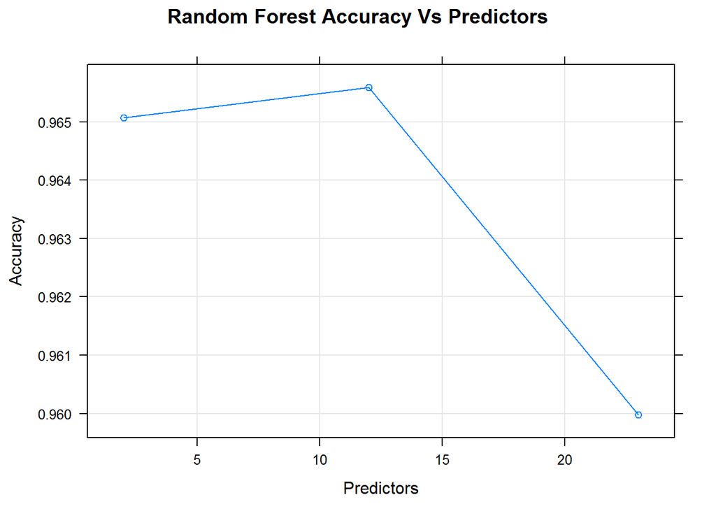

## Conclusion

Random Forrest algorithm produces the best accuracy classifying the dataset with ~97% accuracy rate both on test and cross validation datasets. The out of sample errors is ~2.7% for Random forrest and 16.5% for SVM . Cross validation tests also confirms that Random forrest is a superior model to SVM for classification of this dataset.

Therefore, for this particular dataset and use case, Random Forrest is the recommended model due to its superior accuracy and low out of sample error rates.